# Problem 6

```r
install.packages('glmnet')
install.packages('np')
install.packages('rpart')
```

[output not shown]

```r
install.packages("pROC")
```

[output not shown]

```r
library (dplyr)
library(tidyverse)
library(glmnet)
library(ggplot2)
library("nlme")
library("np")
library(pROC)
library(rpart)
```

### Item 1

#### Subitem a

The idea behind LASSO is that it can select important features from all features and can handle multicollinearity in the data. If group of predictors are highly correlated, lasso picks only one of them and shrinks the others to zero.

Also, it doesn’t assume normality of residuals no more. It might be much better to use it if you have a lot of correlated features and need to do some selection, because simple linear model might be not reliable and can’t filter any features.

#### Subitem b

In Lasso scaling is crucial because we use L1 penalty on the coefficients. If we have different scale for different betas, this will lead to unreliable penalty because it’s possible to change penalty by scaling the data up and down. So we need scaling for L1 to be reliable - penalization scheme is fair to all regressors.

```r
data <- read_tsv('../data/telco.txt') %>% select(-index)
```

```r
data
```

| tenure | age | marital | address | income | ed | employ | retire | gender | longmon | wiremon | churn |
| --- | --- | --- | --- | --- | --- | --- | --- | --- | --- | --- | --- |
| 13 | 44 | Married | 9 | 64 | College degree | 5 | No | Male | 3.70 | 0.00 | Yes |
| 11 | 33 | Married | 7 | 136 | Post-undergraduate degree | 5 | No | Male | 4.40 | 35.70 | Yes |
| 68 | 52 | Married | 24 | 116 | Did not complete high school | 29 | No | Female | 18.15 | 0.00 | No |
| 33 | 33 | Unmarried | 12 | 33 | High school degree | 0 | No | Female | 9.45 | 0.00 | Yes |
| 23 | 30 | Married | 9 | 30 | Did not complete high school | 2 | No | Male | 6.30 | 0.00 | No |
| 41 | 39 | Unmarried | 17 | 78 | High school degree | 16 | No | Female | 11.80 | 0.00 | No |
| 45 | 22 | Married | 2 | 19 | High school degree | 4 | No | Female | 10.90 | 0.00 | Yes |
| 38 | 35 | Unmarried | 5 | 76 | High school degree | 10 | No | Male | 6.05 | 64.90 | No |
| 45 | 59 | Married | 7 | 166 | College degree | 31 | No | Male | 9.75 | 0.00 | No |
| 68 | 41 | Married | 21 | 72 | Did not complete high school | 22 | No | Male | 24.15 | 0.00 | No |

[output cut: 990 more lines]

```r
x <- data %>% select(-longmon)
y <- data %>% select(longmon)
x <- model.matrix(~. -1, x)
y <- as.matrix(y)
```

There are different opinions should binary variables be scaled. I would say it is worth to compare, because sometimes scaling can help the model but will affect the interpretation of the model.

Ed variable is one-hot encoded in the model

I am using glmnet package that does standartization for all variables by default.

#### Subitem c

```r
lasso <- glmnet(x, y, family="gaussian", alpha=1)
lasso_csv <- cv.glmnet(x, y,family="gaussian", alpha=1)
betas <- lasso$beta
```

```r
coef(lasso)
```

```
16 x 73 sparse Matrix of class "dgCMatrix"
```

```
   [[ suppressing 53 column names 's0', 's1', 's2' ... ]]
```

```
(Intercept)                    11.7231 10.63027145 9.63452678 8.72724132 7.9005566 7.1473123 6.4609841 5.8356274
tenure                          .       0.03076137 0.05878999 0.08432862 0.1075985 0.1288011 0.1481201 0.1657229
age                             .       .          .          .          .         .         .         .
maritalMarried                  .       .          .          .          .         .         .         .
maritalUnmarried                .       .          .          .          .         .         .         .
address                         .       .          .          .          .         .         .         .
income                          .       .          .          .          .         .         .         .
edDid not complete high school  .       .          .          .          .         .         .         .
edHigh school degree            .       .          .          .          .         .         .         .
edPost-undergraduate degree     .       .          .          .          .         .         .         .
edSome college                  .       .          .          .          .         .         .         .
employ                          .       .          .          .          .         .         .         .
retireYes                       .       .          .          .          .         .         .         .
genderMale                      .       .          .          .          .         .         .         .
wiremon                         .       .          .          .          .         .         .         .
churnYes                        .       .          .          .          .         .         .         .

(Intercept)                    5.2658257 4.7466436 4.2735842 3.8425501 3.4498079 3.0919558 2.750538520 2.412411156
tenure                         0.1817619 0.1963761 0.2096919 0.2218249 0.2328799 0.2429529 0.250495429 0.254678485
age                            .         .         .         .         .         .         .           .
maritalMarried                 .         .         .         .         .         .         .           .
maritalUnmarried               .         .         .         .         .         .         .           .
address                        .         .         .         .         .         .         .           0.007048171
income                         .         .         .         .         .         .         .           .
edDid not complete high school .         .         .         .         .         .         .           .
edHigh school degree           .         .         .         .         .         .         .           .
edPost-undergraduate degree    .         .         .         .         .         .         .           .
edSome college                 .         .         .         .         .         .         .           .
employ                         .         .         .         .         .         .         0.006686162 0.016525673
retireYes                      .         .         .         .         .         .         .           .
genderMale                     .         .         .         .         .         .         .           .
wiremon                        .         .         .         .         .         .         .           .
churnYes                       .         .         .         .         .         .         .           .

(Intercept)                    2.11556171 1.84922107 1.60543353 1.38330177 1.18090362 0.99648596 0.82845147 0.67534469
tenure                         0.25842403 0.26179754 0.26491968 0.26776460 0.27035679 0.27271869 0.27487077 0.27683166
age                            .          .          .          .          .          .          .          .
maritalMarried                 .          .          .          .          .          .          .          .
maritalUnmarried               .          .          .          .          .          .          .          .
address                        0.01322602 0.01849800 0.02331064 0.02769541 0.03169065 0.03533097 0.03864788 0.04167014
```

[output cut: 83 more lines]

```
maritalUnmarried                .          ......
address                         0.12454285 ......
income                          .          ......
edDid not complete high school -1.14450607 ......
edHigh school degree            .          ......
edPost-undergraduate degree    -0.88356895 ......
edSome college                 -0.32893087 ......
employ                          0.14342126 ......
retireYes                       7.15609836 ......
genderMale                      0.25674364 ......
wiremon                         .          ......
churnYes                        .          ......

 .....suppressing columns in show(); maybe adjust 'options(max.print= *, width = *)'
 ..............................
```

This is plot of coef. values over different lambdas. Top axis indicates the number of non-zero coef. As we can see, log(lambda) ~ 0.5 is a good choise, so lambda ~ 1.6

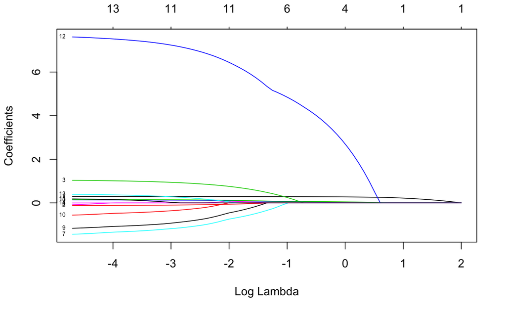

```r
plot.glmnet(lasso, xvar='lambda', label=TRUE)
```

```r
best_lambda <- lasso_csv$lambda.1se
```

```r
best_lambda
```

```
[1] 1.6685
```

Best lambda by cross validation is 1.6685 (this is the biggest lambda with 1% error sd from the smallest error)

### Item 2

#### Subitem a

Linear model

```r
fit.linear <- lm(longmon ~ address, data=data)
```

```r
summary(fit.linear)
```

```
Call:
lm(formula = longmon ~ address, data = data)

Residuals:
    Min      1Q  Median      3Q     Max
-22.547  -5.058  -2.240   2.775  70.311

Coefficients:
            Estimate Std. Error t value Pr(>|t|)
(Intercept)  6.19697    0.44128   14.04   <2e-16 ***
address      0.47841    0.02878   16.62   <2e-16 ***
---
Signif. codes:  0 '***' 0.001 '**' 0.01 '*' 0.05 '.' 0.1 ' ' 1

Residual standard error: 9.176 on 998 degrees of freedom
Multiple R-squared:  0.2168,    Adjusted R-squared:  0.216
F-statistic: 276.3 on 1 and 998 DF,  p-value: < 2.2e-16
```

Regression plot

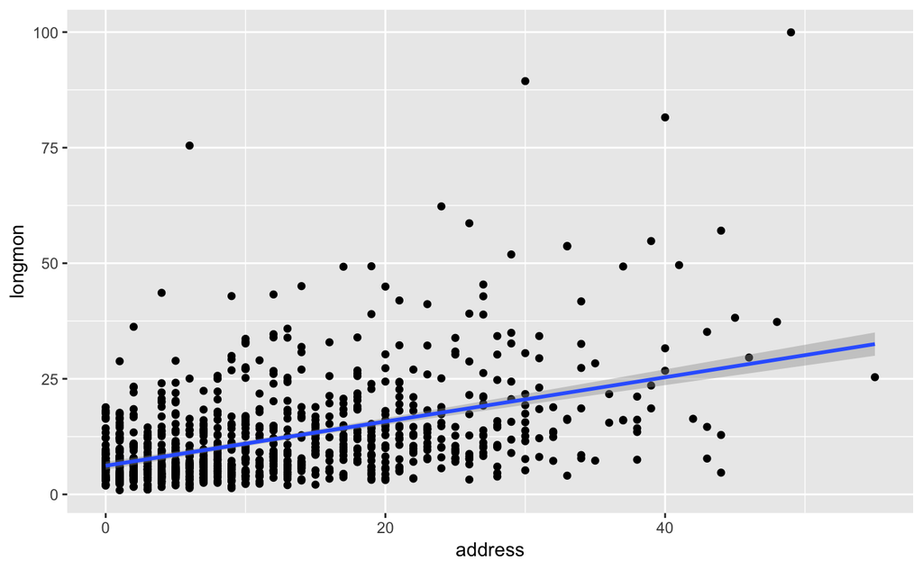

```r
ggplot(data, aes(y=longmon, x=address)) + geom_point() + geom_smooth(method='lm')
```

MSE of the fitted linear model

```r
mean(resid(fit.linear)^2)
```

```
[1] 84.0315
```

#### Subitem b

Non linear model: $b_0 + e^{address * b_1 + b_2} + b_3 * address$

```r
models.nl <- nls(longmon ~ b0  + exp(address*(b1) + b2) + b3 * address, data=data, start=list(b0=1, b1=0.1, b2=1, b3=1), control = list(maxiter = 500))
```

```r
summary(models.nl)
```

```
Formula: longmon ~ b0 + exp(address * (b1) + b2) + b3 * address

Parameters:
   Estimate Std. Error t value Pr(>|t|)
b0  4.64800    8.79470   0.529    0.597
b1  0.04601    0.05221   0.881    0.378
b2  0.91474    3.65643   0.250    0.803
b3  0.19493    0.39026   0.499    0.618

Residual standard error: 9.13 on 996 degrees of freedom

Number of iterations to convergence: 12
Achieved convergence tolerance: 9.277e-06
```

MSE of the non linear model

```r
mean(resid(models.nl)^2)
```

```
[1] 83.02237
```

Non Linear model plot

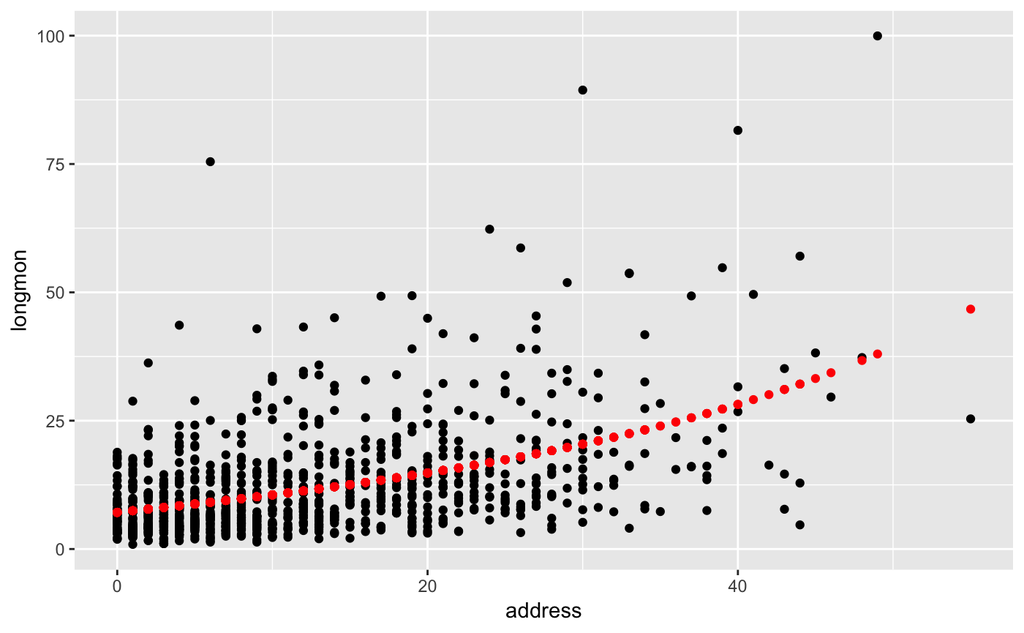

```r
ggplot(data, aes(y=longmon, x=address)) + geom_point() + geom_point(y=predict(models.nl), color='red')
```

As we can see, non linear model is slightly better comparing MSE to the linear model

#### Subitem c

In general, there is no closed-form expression for the best-fitting parameters, as there is in linear regression. Usually numerical optimization algorithms are applied to determine the best-fitting parameters. Also, residual normality is not required, unbiased estimates are much harder.

### Item 3

#### Subitem a

If we choose bandwidth too big - we will get very smooth curve that will have small sensitivity, which will lead to underfitting the data. If we choose small bandwidth - we will have high variance and overfitting the data.

#### Subitem b

Fitting regression

```r
nw.bw = npregbw(longmon ~ address, data=data,  regtype = "lc", bwmethod = "cv.aic")
```

```
Multistart 1 of 1 |
Multistart 1 of 1 |
Multistart 1 of 1 |
Multistart 1 of 1 /
Multistart 1 of 1 |
Multistart 1 of 1 |
```

```r
model = npreg(bws=nw.bw);
```

```r
summary(model)
```

```
Regression Data: 1000 training points, in 1 variable(s)
                address
Bandwidth(s): 0.6319911

Kernel Regression Estimator: Local-Constant
Bandwidth Type: Fixed
Residual standard error: 8.647054
R-squared: 0.3038761

Continuous Kernel Type: Second-Order Gaussian
No. Continuous Explanatory Vars.: 1
```

Data plot

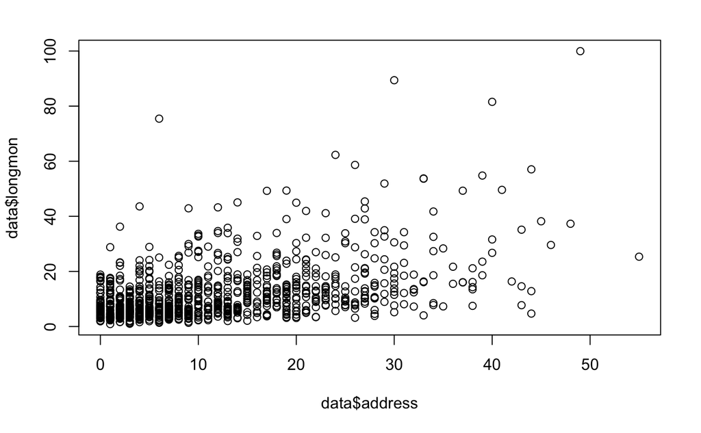

```r
plot(data$address, data$longmon)
```

Regression plot

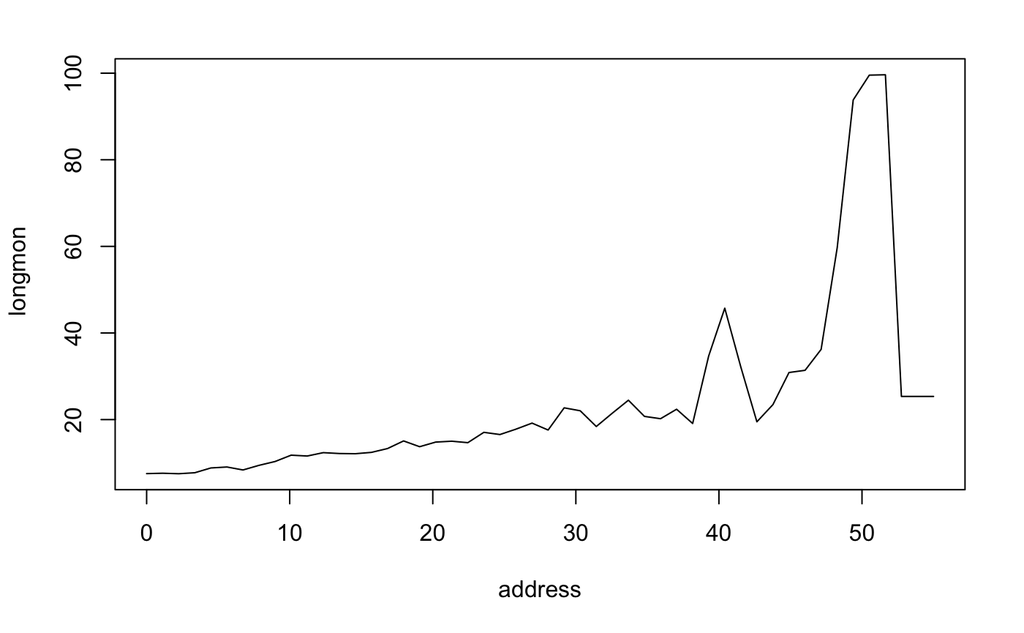

```r
npplot(nw.bw, type="l")
```

#### Subitem c

We can see that MSE is much lower comparing to the non linear model from previous item

```r
mean(resid(model)^2)
```

```
[1] 74.77155
```

### Item 4

#### Subitem a

Fitted logistic regression

```r
m.log <- glm(as.factor(churn) ~ ., data=data, family=binomial(logit))
```

```r
summary(m.log)
```

```
Call:
glm(formula = as.factor(churn) ~ ., family = binomial(logit),
    data = data)

Deviance Residuals:
    Min       1Q   Median       3Q      Max
-1.6891  -0.7859  -0.4399   0.9089   2.6960

Coefficients:
                                 Estimate Std. Error z value Pr(>|z|)
(Intercept)                     0.9740331  0.3900119   2.497  0.01251 *
tenure                         -0.0316908  0.0070667  -4.485 7.31e-06 ***
age                             0.0007173  0.0108795   0.066  0.94743
maritalUnmarried               -0.0441584  0.1634581  -0.270  0.78704
address                        -0.0146731  0.0128014  -1.146  0.25171
income                          0.0005143  0.0010434   0.493  0.62206
edDid not complete high school -0.7927333  0.2709599  -2.926  0.00344 **
edHigh school degree           -0.5490261  0.2234004  -2.458  0.01399 *
edPost-undergraduate degree     0.1387381  0.3160821   0.439  0.66071
edSome college                 -0.3752715  0.2265733  -1.656  0.09766 .
employ                         -0.0322478  0.0151843  -2.124  0.03369 *
retireYes                      -0.6151134  0.6906561  -0.891  0.37313
genderMale                     -0.0705760  0.1597342  -0.442  0.65861
longmon                        -0.0384885  0.0217376  -1.771  0.07663 .
wiremon                         0.0141263  0.0042629   3.314  0.00092 ***
---
Signif. codes:  0 '***' 0.001 '**' 0.01 '*' 0.05 '.' 0.1 ' ' 1

(Dispersion parameter for binomial family taken to be 1)

    Null deviance: 1174.39  on 999  degrees of freedom
Residual deviance:  958.72  on 985  degrees of freedom
AIC: 988.72

Number of Fisher Scoring iterations: 6
```

#### Subitem b

Tenure estimated parameter is = -0.03169 - the bigger tenure value the less chance of churn. The odds changes by 0.97 for one unit increase of tenure

#### Subitem c

Selection of the best model:

```r
step(glm(as.factor(churn) ~ ., data=data, family=binomial(logit)))
```

```
Start:  AIC=988.72
as.factor(churn) ~ tenure + age + marital + address + income +
    ed + employ + retire + gender + longmon + wiremon

          Df Deviance     AIC
- age      1   958.72  986.72
- marital  1   958.79  986.79
- gender   1   958.91  986.91
- income   1   958.94  986.94
- retire   1   959.59  987.59
- address  1   960.04  988.04
<none>         958.72  988.72
- longmon  1   962.16  990.16
- employ   1   963.24  991.24
- ed       4   971.17  993.17
- wiremon  1   969.53  997.53
- tenure   1   979.45 1007.45

Step:  AIC=986.72
as.factor(churn) ~ tenure + marital + address + income + ed +
    employ + retire + gender + longmon + wiremon

          Df Deviance     AIC
- marital  1   958.80  984.80
- gender   1   958.91  984.91
- income   1   958.95  984.95
- retire   1   959.66  985.66
- address  1   960.33  986.33
<none>         958.72  986.72
- longmon  1   962.18  988.18
- employ   1   964.29  990.29
- ed       4   971.21  991.21
- wiremon  1   969.54  995.54
- tenure   1   979.45 1005.45

Step:  AIC=984.8
as.factor(churn) ~ tenure + address + income + ed + employ +
    retire + gender + longmon + wiremon

          Df Deviance     AIC
```

[output cut: 63 more lines]

```

Call:  glm(formula = as.factor(churn) ~ tenure + ed + employ + longmon +
    wiremon, family = binomial(logit), data = data)

Coefficients:
                   (Intercept)                          tenure  edDid not complete high school
                       0.90388                        -0.03291                        -0.82253
          edHigh school degree     edPost-undergraduate degree                  edSome college
                      -0.57015                         0.14405                        -0.37171
                        employ                         longmon                         wiremon
                      -0.03384                        -0.04076                         0.01449

Degrees of Freedom: 999 Total (i.e. Null);  991 Residual
Null Deviance:      1174
Residual Deviance: 962.4    AIC: 980.4
```

Factors with positive influence to the churn probability: edPost-undergraduate degree, wiremon, intercept Factors with negative influence to the churn probability: longmon, employ, edSome college, edHigh school degree, edDid not complete high school, tenure

Seems people that use internet have increased probability of churn (which can be the indicator of bad internet services).

```r
log.best <- glm(formula = as.factor(churn) ~ tenure + ed + employ + longmon +
    wiremon, family = binomial(logit), data = data)
```

#### Subitem d

Formula for computing the logits of the first:

$ = 0.9 -0.033x_{tenure} - 0.822x_{edDid not complete high school} - 0.57x_{edHigh school degree} + 0.144x_{edPost-undergraduate degree} - 0.371x_{edSome college} - 0.0338x_{employ} - 0.04x_{logmon} + 0.0144x_{wiremon} $

after that we can compute probabilities as $y_{prediciton} = \frac{e^\hat{y}}{(1+e^\hat{y})}$

We can select the threshold to detect the class (usually 0.5) and if probability > 0.5 - this is class 1, if <0.5 - this is class 0.

```r
pred <- predict(log.best, type='response')[50:55]
```

```r
data[50:55,]
```

| tenure | age | marital | address | income | ed | employ | retire | gender | longmon | wiremon | churn |
| --- | --- | --- | --- | --- | --- | --- | --- | --- | --- | --- | --- |
| 5 | 36 | Unmarried | 14 | 29 | High school degree | 9 | No | Female | 3.25 | 26.75 | Yes |
| 30 | 34 | Married | 4 | 27 | High school degree | 1 | No | Male | 6.30 | 0.00 | Yes |
| 56 | 52 | Married | 28 | 49 | High school degree | 12 | No | Male | 24.75 | 0.00 | No |
| 10 | 22 | Unmarried | 0 | 24 | College degree | 0 | No | Male | 7.80 | 30.05 | No |
| 7 | 26 | Married | 3 | 26 | High school degree | 2 | No | Male | 4.85 | 0.00 | No |
| 52 | 27 | Unmarried | 6 | 47 | Some college | 5 | No | Male | 6.25 | 0.00 | No |

Probabilities

```r
pred
```

```
        50         51         52         53         54         55
0.52989736 0.28005076 0.05097613 0.66646593 0.45959119 0.16754259
```

#### Subitem e

Now we can build a classification table:

```r
predict <- predict(log.best, type = 'response')
```

Classification table with 0.5 threshold Left is ground truth and top is predicted value. We can see that we have 668 correctly classified non-churn customers, 58 clients that we classified as churn but in reality not (false positive), 169 clients that we classified as non-churn but in reality they are (false negative) and 105 as churn customers(which are real churn customers).

```r
#confusion matrix
table(data$churn, predict > 0.5)
```

```
      FALSE TRUE
  No    668   58
  Yes   169  105
```

#### Subitem f

Best threshold will be the value closest to the left top corner on the curve.

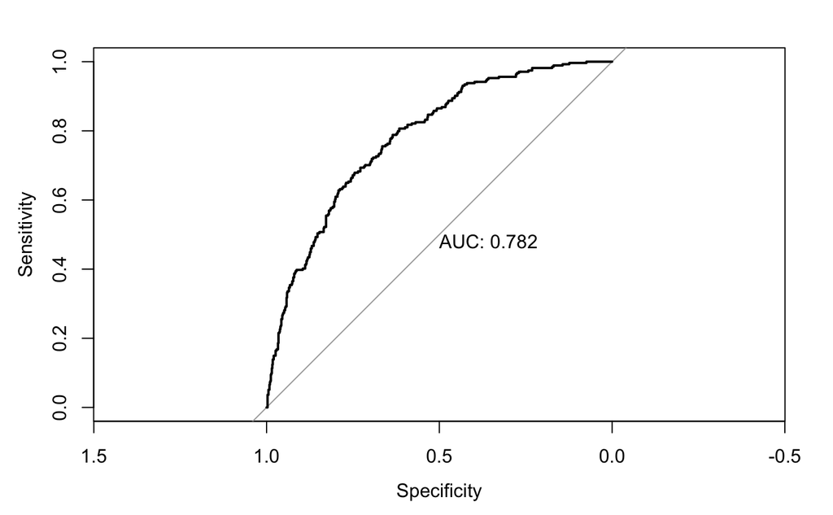

```r
my_roc <- roc(as.factor(data$churn), predict(log.best))
best_thr <-  coords(my_roc, "best", ret = "threshold")
best_thr <- exp(best_thr) / (1+ exp(best_thr))
plot(my_roc, print.auc = TRUE)
```

Best threshold:

```r
best_thr
```

```
[1] 0.3389046
```

#### Subitem g

With this threshold we gained more false positive errors, but we improved the quality of churn prediciton. Now the chance that we will miss the potential churn is lower, but we also have bigger under risk of false positive.

```r
#confusion matrix
table(data$churn, predict > best_thr)
```

```
      FALSE TRUE
  No    541  185
  Yes    88  186
```

### Item 5

#### Subitem a

To perform splitting, algorithm will try to look for a splitting point from the values range of tenure that minimized the value of error function sum for splits. The error funciton used for regression tree is sum of squared errors. So once the splitting point is found, we have left and right subtree divided by the splitting point.

```r
tree = rpart(longmon ~ ., data=data, control = rpart.control(maxdepth = 10))
```

#### Subitem b

There are multiple approaches to pruning trees.

One is prune the tree after the tree is built. This can be done using the `cp` complexity parameter. It recursively snipping off the least important splits based on cp parameter. (R function: `prune`)

Another approach is to limit the max depth of the tree on building so we don’t have to prune it after.

```r
tree
```

```
n= 1000

node), split, n, deviance, yval
      * denotes terminal node

 1) root 1000 107294.400 11.723100
   2) tenure< 66.5 902  32770.550  9.396064
     4) tenure< 45.5 642   8124.189  6.888240
       8) tenure< 19.5 293   1417.825  4.787201 *
       9) tenure>=19.5 349   4327.086  8.652149 *
     5) tenure>=45.5 260  10638.810 15.588460
      10) tenure< 53.5 102   2007.082 12.852450 *
      11) tenure>=53.5 158   7375.254 17.354750 *
   3) tenure>=66.5 98  24682.920 33.141330
     6) tenure< 71.5 67   5737.410 27.108960 *
     7) tenure>=71.5 31  11237.970 46.179030
      14) employ< 31.5 16   1891.444 37.543750 *
      15) employ>=31.5 15   6880.811 55.390000 *
```